# Лабораторная работа № 2

## Проверка системного журнала

В журнале systemd проверена работа служб после изменения конфигурации.

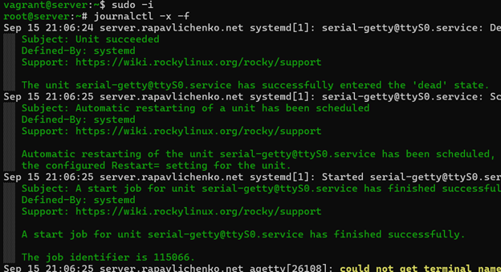

## Запуск DNS-сервера

Служба `named` перезапущена и перешла в состояние `active`.

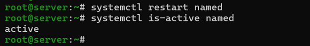

# Результаты

## Проверка прямой зоны

Команда `dig ns.rapavlichenko.net` вернула авторитетный ответ `192.168.1.1`.

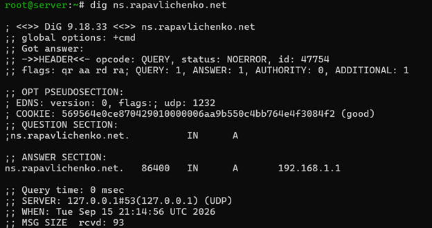

## Проверка записей зоны

Команды `host` подтвердили работу A-, NS-, SOA- и PTR-записей.

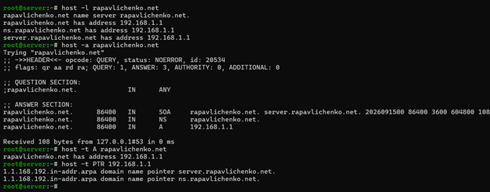

# Автоматизация

## Сохранение рабочей конфигурации

Файлы BIND и зоны скопированы в каталог `provision/server/dns` для последующего автоматического развёртывания.

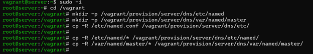

## Сценарий настройки DNS

Сценарий `dns.sh` устанавливает пакеты, размещает конфигурацию, настраивает права, SELinux, firewalld и NetworkManager, затем запускает `named`.

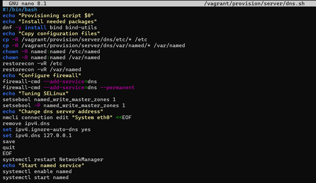

## Подключение сценария в Vagrantfile

Provisioner `server dns` запускает сценарий при развёртывании серверной виртуальной машины.

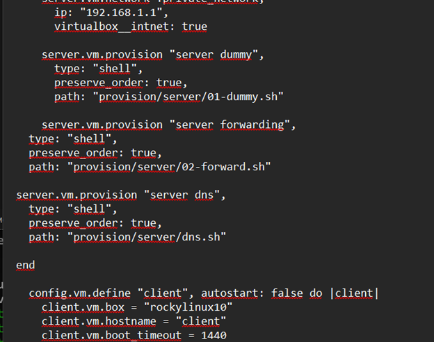

# Выводы

## Выводы

В ходе работы были получены практические навыки установки и настройки DNS-сервера BIND. Были созданы прямая и обратная зоны, настроены сетевые параметры, firewalld и SELinux, проверено разрешение имён и подготовлена автоматизация конфигурации сервера средствами Vagrant.